# HDAT9600 Final Team Assignment

Please see course outline / ‘Announcements’ for submission deadline

## Instructions

- This file (hdat9600assess4_teamX.Rmd) is the R Markdown document in which you need to complete your HDAT9600 final team assignment.
- You should rename the file by replacing ‘X’ with your team number.
- This assignment is assessed and will count for 30% of the total course marks.
- The assignment comprises two tasks. The first task will focus on logistic regression, and the second task will focus on survival analysis.
- There is no word limit, nor limit on the length of your submitted Rmarkdown (i.e. this file) document.
- The **rendered** html document, were it to be printed, should be **no more** than about 10 A4 pages in length.
- Your html rendered document should include sufficient code chunks, output, and visual display as necessary to support your discursive commentary addressing each task. You may therefore wish to **suppress some of the contents** of your Rmarkdown file from appearing within the rendered document.
- The rendered (html) document will be the submission primarily considered when awarding credit. However, the Rmarkdown file may also be considered as deemed appropriate.
- **Excessively long reports will be penalised** by cessation of awarding of credit after roughly 10 pages of content.
- All tasks are intended to be completed as a team. Have fun discussing the tasks and working together.

Don’t hesitate to ask the course convenor for help via OpenLearning. The course instructor are happy to point you in the right direction and to make suggestions, but they won’t, of course, complete your assessment for you!

## Data for this assessment

The data used for this assessment consist of records from Intensive Care Unit (ICU) hospital stays in the USA. All patients were adults who were admitted for a wide variety of reasons. ICU stays of less than 48 hours have been excluded.

The source data for the assessment are data made freely available for the 2012 MIT PhysioNet/Computing for Cardiology Challenge. Details are provided [here](https://physionet.org/challenge/2012/). Training Set A data have been used. The original data has been modified and assembled to suit the purpose of this assessment. While not required for the purposes of this assignment, full details of the preparatory work can be found in the ‘hdat9600assess4_final_data_prep’ file.

The dataframe consists of 120 variables, which are defined as follows:

#### Patient Descriptor Variables

*RecordID:* a unique integer for each ICU stay

*Age:* years

*Gender:* male/female

*Height:* cm

*ICUType:* Coronary Care Unit; Cardiac Surgery Recovery Unit; Medical ICU; Surgical ICU

*Length_of_stay:* The number of days between the patient’s admission to the ICU and the end of hospitalisation

*Survival:* The number of days between ICU admission and death for patients who died

#### Outcome Variables

*in_hospital_death:* 0:survivor/1:died in-hospital **this is the outcome variable for Task 1: Logistic Regression**

*Status:* True/False **this is the censoring variable for Task 2: Survival Analysis**

*Days:* Length of survival (in days) **this is the survival time variable for Task 2: Survival Analysis**

#### Clinical Variables

*Use the hyperlinks below to find out more about the clinical meaning of each variable.* The first two clinical variables are summary scores that are used to assess patient condition and risk.

- SAPS-I score - Simplified Acute Physiological Score [Le Gall et al., 1984](http://www.ncbi.nlm.nih.gov/pubmed/6499483)
- SOFA score - Sequential Organ Failure Assessment [Ferreira et al., 2001](http://www.ncbi.nlm.nih.gov/pubmed/11594901)

The following 36 clinical measures were assessed at multiple timepoints during each patient’s ICU stay. For each of the 36 clinical measures, you are given 3 summary variables: a) The minimum value during the first 24 hours in ICU (_min), b) The maximum value during the first 24 hours in ICU (_max), and c) The difference between the mean and the most extreme values during the first 24 hours in ICU (_diff). For example, for the clinical measure Cholesterol, these three variables are labelled ‘Cholesterol_min’, ‘Cholesterol_max’, and ‘Cholesterol_diff’.

- [Albumin](http://en.wikipedia.org/wiki/Human_serum_albumin) (g/dL)
- [ALP](http://en.wikipedia.org/wiki/Alkaline_phosphatase) [Alkaline phosphatase (IU/L)]
- [ALT](http://en.wikipedia.org/wiki/Alanine_transaminase) [Alanine transaminase (IU/L)]
- [AST](http://en.wikipedia.org/wiki/Aspartate_transaminase) [Aspartate transaminase (IU/L)]
- Bilirubin (mg/dL)
- BUN [Blood urea nitrogen (mg/dL)]
- Cholesterol (mg/dL)
- [Creatinine](http://en.wikipedia.org/wiki/Serum_creatinine#Plasma_creatinine) [Serum creatinine (mg/dL)]
- [DiasABP](http://en.wikipedia.org/wiki/Diastolic_blood_pressure) [Invasive diastolic arterial blood pressure (mmHg)]
- [FiO2](http://en.wikipedia.org/wiki/FIO2) [Fractional inspired O<sub>2</sub> (0-1)]
- [GCS](http://en.wikipedia.org/wiki/Glasgow_coma_score) [Glasgow Coma Score (3-15)]
- [Glucose](http://en.wikipedia.org/wiki/Serum_glucose) [Serum glucose (mg/dL)]
- [HCO3](http://en.wikipedia.org/wiki/Bicarbonate#Diagnostics) [Serum bicarbonate (mmol/L)]
- [HCT](http://en.wikipedia.org/wiki/Hematocrit) [Hematocrit (%)]
- [HR](http://en.wikipedia.org/wiki/Heart_rate) [Heart rate (bpm)]
- [K](http://en.wikipedia.org/wiki/Hypokalemia) [Serum potassium (mEq/L)]
- [Lactate](http://en.wikipedia.org/wiki/Lactic_acid) (mmol/L)
- [Mg](http://en.wikipedia.org/wiki/Magnesium#Biological_role) [Serum magnesium (mmol/L)]
- [MAP](http://en.wikipedia.org/wiki/Mean_arterial_pressure) [Invasive mean arterial blood pressure (mmHg)]
- [MechVent](http://en.wikipedia.org/wiki/Mechanical_ventilation) [Mechanical ventilation respiration (0:false, or 1:true)]
- [Na](http://en.wikipedia.org/wiki/Serum_sodium) [Serum sodium (mEq/L)]
- [NIDiasABP](http://en.wikipedia.org/wiki/Diastolic_blood_pressure) [Non-invasive diastolic arterial blood pressure (mmHg)]
- [NIMAP](http://en.wikipedia.org/wiki/Mean_arterial_pressure) [Non-invasive mean arterial blood pressure (mmHg)]
- [NISysABP](http://en.wikipedia.org/wiki/Systolic_blood_pressure) [Non-invasive systolic arterial blood pressure (mmHg)]
- [PaCO2](http://en.wikipedia.org/wiki/Arterial_blood_gas) [partial pressure of arterial CO<sub>2</sub> (mmHg)]
- [PaO2](http://en.wikipedia.org/wiki/Arterial_blood_gas) [Partial pressure of arterial O<sub>2</sub> (mmHg)]
- [pH](http://en.wikipedia.org/wiki/Arterial_blood_gas) [Arterial pH (0-14)]
- Platelets (cells/nL)
- [RespRate](http://en.wikipedia.org/wiki/Respiratory_physiology) [Respiration rate (bpm)]
- [SaO2](http://en.wikipedia.org/wiki/Arterial_blood_gas) [O<sub>2</sub> saturation in hemoglobin (%)]
- [SysABP](http://en.wikipedia.org/wiki/Systolic_blood_pressure) [Invasive systolic arterial blood pressure (mmHg)]
- [Temp](http://en.wikipedia.org/wiki/Normal_human_body_temperature) [Temperature (°C)]
- [TropI](http://en.wikipedia.org/wiki/Troponin) [Troponin-I (μg/L)]
- [TropT](http://en.wikipedia.org/wiki/Troponin) [Troponin-T (μg/L)]
- [Urine](http://en.wikipedia.org/wiki/Fluid_balance) [Urine output (mL)]
- [WBC](http://en.wikipedia.org/wiki/Reference_ranges_for_blood_tests#Hematology) [White blood cell count (cells/nL)]
- Weight (kg)

## EDA

1.Getting an overview of dataset

```r
icu_patients_df1 <- readRDS("icu_patients_df1.rds")


#check how many rows in total, #2061
nrow(icu_patients_df1)
```

```
## [1] 2061
```

```r
#check how many variables in the data set #120
ls(icu_patients_df1)
```

```
##   [1] "Age"               "Albumin_diff"      "Albumin_max"
##   [4] "Albumin_min"       "ALP_diff"          "ALP_max"
##   [7] "ALP_min"           "ALT_diff"          "ALT_max"
##  [10] "ALT_min"           "AST_diff"          "AST_max"
##  [13] "AST_min"           "Bilirubin_diff"    "Bilirubin_max"
##  [16] "Bilirubin_min"     "BUN_diff"          "BUN_max"
##  [19] "BUN_min"           "Cholesterol_diff"  "Cholesterol_max"
##  [22] "Cholesterol_min"   "Creatinine_diff"   "Creatinine_max"
##  [25] "Creatinine_min"    "Days"              "DiasABP_diff"
##  [28] "DiasABP_max"       "DiasABP_min"       "FiO2_diff"
##  [31] "FiO2_max"          "FiO2_min"          "GCS_diff"
##  [34] "GCS_max"           "GCS_min"           "Gender"
##  [37] "Glucose_diff"      "Glucose_max"       "Glucose_min"
##  [40] "HCO3_diff"         "HCO3_max"          "HCO3_min"
##  [43] "HCT_diff"          "HCT_max"           "HCT_min"
```

[output cut: 25 more lines]

```r
#check how many missing valus which is #11193
sum(is.na(icu_patients_df1))
```

```
## [1] 11193
```

Getting an overview of dataset, and there are 2061 rows, 120 variables and 11193 missing values at the very beginning

2.Remove all variables that have more than 20% missing value and check the dataset again

```r
icu_removed_na <- icu_patients_df1[colSums(is.na(icu_patients_df1))/nrow(icu_patients_df1) < .2]
icu_removed_na <- na.omit(icu_removed_na)

#check how many rows, 1855
nrow(icu_removed_na)
```

```
## [1] 1855
```

```r
#check how many variables, 103
ls(icu_removed_na)
```

```
##   [1] "Age"               "Albumin_diff"      "Albumin_max"
##   [4] "Albumin_min"       "ALP_diff"          "ALP_max"
##   [7] "ALP_min"           "ALT_diff"          "ALT_max"
##  [10] "ALT_min"           "AST_diff"          "AST_max"
##  [13] "AST_min"           "Bilirubin_diff"    "Bilirubin_max"
##  [16] "Bilirubin_min"     "BUN_diff"          "BUN_max"
##  [19] "BUN_min"           "Cholesterol_diff"  "Cholesterol_max"
##  [22] "Cholesterol_min"   "Creatinine_diff"   "Creatinine_max"
##  [25] "Creatinine_min"    "Days"              "FiO2_diff"
##  [28] "FiO2_max"          "FiO2_min"          "GCS_diff"
##  [31] "GCS_max"           "GCS_min"           "Gender"
##  [34] "Glucose_diff"      "Glucose_max"       "Glucose_min"
##  [37] "HCO3_diff"         "HCO3_max"          "HCO3_min"
##  [40] "HCT_diff"          "HCT_max"           "HCT_min"
##  [43] "HR_diff"           "HR_max"            "HR_min"
```

[output cut: 20 more lines]

There are 1855 rows and 103 variables left

3. Check the summary of all variables

```r
summary(icu_removed_na)
```

```
##     RecordID      Length_of_stay       SAPS1            SOFA
##  Min.   :132540   Min.   : -1.00   Min.   : 1.00   Min.   :-1.000
##  1st Qu.:133910   1st Qu.:  6.00   1st Qu.:11.00   1st Qu.: 4.000
##  Median :135195   Median : 10.00   Median :15.00   Median : 7.000
##  Mean   :135173   Mean   : 14.34   Mean   :15.18   Mean   : 6.835
##  3rd Qu.:136484   3rd Qu.: 18.00   3rd Qu.:19.00   3rd Qu.:10.000
##  Max.   :137740   Max.   :154.00   Max.   :34.00   Max.   :22.000
##  in_hospital_death      Days        Status             Age
##  Min.   :0.0000    Min.   :   1   Mode :logical   Min.   :16.00
##  1st Qu.:0.0000    1st Qu.: 246   FALSE:1159      1st Qu.:53.00
##  Median :0.0000    Median :2408   TRUE :696       Median :67.00
##  Mean   :0.1472    Mean   :1631                   Mean   :64.65
##  3rd Qu.:0.0000    3rd Qu.:2408                   3rd Qu.:78.00
##  Max.   :1.0000    Max.   :2408                   Max.   :90.00
##   Albumin_diff      Albumin_max     Albumin_min       ALP_diff
##  Min.   :0.01866   Min.   :1.100   Min.   :1.100   Min.   :   0.148
##  1st Qu.:0.28134   1st Qu.:2.600   1st Qu.:2.600   1st Qu.:  21.852
##  Median :0.48134   Median :3.000   Median :3.000   Median :  37.852
##  Mean   :0.56831   Mean   :3.046   Mean   :3.009   Mean   :  56.142
##  3rd Qu.:0.81866   3rd Qu.:3.500   3rd Qu.:3.500   3rd Qu.:  54.852
##  Max.   :2.31866   Max.   :5.300   Max.   :5.300   Max.   :1408.148
##     ALP_max          ALP_min          ALT_diff            ALT_max
##  Min.   :  19.0   Min.   :  19.0   Min.   :    0.446   Min.   :    3.0
##  1st Qu.:  56.0   1st Qu.:  58.0   1st Qu.:   89.446   1st Qu.:   17.0
##  Median :  78.0   Median :  76.0   Median :  102.446   Median :   30.0
##  Mean   : 104.9   Mean   : 100.5   Mean   :  152.935   Mean   :  116.9
##  3rd Qu.: 109.0   3rd Qu.: 104.0   3rd Qu.:  108.446   3rd Qu.:   69.0
##  Max.   :1504.0   Max.   :1339.0   Max.   :10319.554   Max.   :10440.0
##     ALT_min           AST_diff            AST_max           AST_min
##  Min.   :   1.00   Min.   :    0.647   Min.   :    5.0   Min.   :   5.0
##  1st Qu.:  17.00   1st Qu.:  124.353   1st Qu.:   26.5   1st Qu.:  24.0
##  Median :  30.00   Median :  142.353   Median :   51.0   Median :  42.0
##  Mean   :  89.16   Mean   :  227.527   Mean   :  188.2   Mean   : 116.9
##  3rd Qu.:  68.50   3rd Qu.:  152.353   3rd Qu.:  133.0   3rd Qu.:  87.0
##  Max.   :9240.00   Max.   :15870.647   Max.   :16040.0   Max.   :7960.0
##  Bilirubin_diff     Bilirubin_max    Bilirubin_min       BUN_diff
##  Min.   : 0.03596   Min.   : 0.100   Min.   : 0.100   Min.   :  0.473
##  1st Qu.: 1.06404   1st Qu.: 0.400   1st Qu.: 0.400   1st Qu.:  7.473
##  Median : 1.36404   Median : 0.700   Median : 0.600   Median : 11.527
##  Mean   : 2.00339   Mean   : 1.773   Mean   : 1.592   Mean   : 15.378
```

[output cut: 134 more lines]

```
##  Max.   :4900.78   Max.   :5000   Max.   :600.00   Max.   :143.46685
##     WBC_max         WBC_min        Weight_diff          Weight_max
##  Min.   :  0.1   Min.   :  0.10   Min.   :  0.00012   Min.   : 34.60
##  1st Qu.:  9.4   1st Qu.:  7.70   1st Qu.:  7.50012   1st Qu.: 66.00
##  Median : 12.6   Median : 10.50   Median : 14.79988   Median : 80.00
##  Mean   : 14.1   Mean   : 11.58   Mean   : 18.21444   Mean   : 82.72
##  3rd Qu.: 17.2   3rd Qu.: 14.20   3rd Qu.: 24.85000   3rd Qu.: 94.70
##  Max.   :155.6   Max.   :128.30   Max.   :149.30012   Max.   :230.00
##    Weight_min
##  Min.   : 34.6
##  1st Qu.: 65.0
##  Median : 77.7
##  Mean   : 80.9
##  3rd Qu.: 92.0
##  Max.   :230.0
```

4. the SOFA score should be in the range between 0-24, and length of stay shouldn’t be negative so delete

```r
icu_removed_na$SOFA[icu_removed_na$SOFA == -1] <- NA

icu_removed_na$Length_of_stay[icu_removed_na$Length_of_stay == -1] <- NA


icu_removed_na <- na.omit(icu_removed_na)




#1819 rows
nrow(icu_removed_na)
```

```
## [1] 1819
```

```r
#103 variables
ncol(icu_removed_na)
```

```
## [1] 103
```

```r
sum(is.na(icu_removed_na))
```

```
## [1] 0
```

After data clean, there are 1819 rows, 103 variables and 0 missing values finally

**Note:** icu_patients_df1 is an imputed (i.e. missing values are ‘derived’) version of icu_patients_df0. This assessment does not concern the methods used for imputation.

# Task 1

In this task, you are required to develop a logistic regression model using the `icu_patients_df1` data set which adequately explains or predicts the `in_hospital_death` variable as the outcome using a subset of the available predictor variables. You should fit a series of models, evaluating each one, before you present your final model. Your final model should **not** include all the predictor variables, just a small subset of them, which you have selected based on statistical significance and/or background knowledge. It is perfectly acceptable to include predictor variables in your final model which are not statistically significant, as long as you justify their inclusion on medical or physiological grounds (you will not be marked down if your medical justification is not exactly correct or complete, but do you best). Aim for between five and ten predictor variables (slightly more or fewer is OK). You should assess each model you consider for goodness of fit and other relevant statistics to help you choose between them. For your final model, present a set of diagnostic statistics and/or charts and comment on them. You don’t need to do an exhaustive exploratory data analysis of all the variables in the data set, but you should examine those variables that you use in your model. Finally, re-fit your final model to the unimputed data frame (`icu_patients_df0.rds`) and comment on any differences you find compared to the same model fitted to the imputed data.

### Hints

1. Select an initial subset of explanatory variables that you will use to predict the risk of in-hospital death. Justify your choice.
2. Conduct basic exploratory data analysis on your variables of choice.
3. Fit appropriate univariate logistic regression models.
4. Fit an appropriate series of multivariable logistic regression models, justifying your approach. Assess each model you consider for goodness of fit and other relevant statistics.
5. Present your final model. Your final model should **not** include all the predictor variables, just a small subset of them, which you have selected based on statistical significance and/or background knowledge.
6. For your final model, present a set of diagnostic statistics and/or charts and comment on them.
7. Write a paragraph or two summarising the most important findings of your final model. Include the most important values from the statistical output, and a simple clinical interpretation.

**Create your response to this task here, as a mixture of embedded (`knitr`) R code and any resulting outputs, and explanatory or commentary text.**

```r
# Calculate P value between each selected variables and in_hospital_hospital_death
icu_removed_na$hospital_death <- factor(icu_removed_na$in_hospital_death, labels=c("Survivor","in_hospital_death"))

# Remove some descriptor and outcome variables
data_frame <- icu_removed_na %>%
       dplyr::select(-RecordID, -Length_of_stay, -Status, -Days, -in_hospital_death)

Pvalue_each <- tbl_summary(data_frame, by=hospital_death) %>%
          add_p() %>%
          modify_header(label = "**Variable**") %>%
          bold_labels()
Pvalue_each
```

| **Variable** | **Survivor**, N = 1,550<sup>1</sup> | **in_hospital_death**, N = 269<sup>1</sup> | **p-value**<sup>2</sup> |
| --- | --- | --- | --- |
| SAPS1 | 15.0 (11.0, 18.0) | 18.0 (14.0, 21.0) | <0.001 |
| SOFA | 7.0 (4.0, 9.0) | 9.0 (6.0, 12.0) | <0.001 |
| Age | 66 (52, 77) | 76 (62, 83) | <0.001 |
| Albumin_diff | 0.48 (0.28, 0.82) | 0.52 (0.28, 0.88) | 0.5 |
| Albumin_max | 3.00 (2.70, 3.50) | 2.80 (2.50, 3.30) | <0.001 |
| Albumin_min | 3.00 (2.60, 3.50) | 2.80 (2.40, 3.30) | <0.001 |
| ALP_diff | 38 (22, 54) | 37 (20, 58) | >0.9 |
| ALP_max | 76 (56, 105) | 84 (61, 129) | 0.003 |
| ALP_min | 74 (57, 103) | 82 (63, 116) | 0.002 |
| ALT_diff | 102 (89, 108) | 103 (90, 110) | 0.061 |
| ALT_max | 29 (17, 68) | 31 (17, 84) | 0.3 |
| ALT_min | 30 (17, 68) | 29 (17, 70) | 0.8 |
| AST_diff | 143 (124, 152) | 141 (120, 152) | 0.8 |
| AST_max | 50 (25, 128) | 61 (30, 160) | 0.018 |
| AST_min | 42 (24, 84) | 47 (27, 119) | 0.025 |
| Bilirubin_diff | 1.36 (1.06, 1.46) | 1.36 (1.06, 1.56) | 0.4 |
| Bilirubin_max | 0.70 (0.40, 1.20) | 0.90 (0.40, 1.70) | <0.001 |
| Bilirubin_min | 0.60 (0.40, 1.00) | 0.70 (0.40, 1.50) | <0.001 |
| BUN_diff | 12 (7, 16) | 13 (7, 27) | <0.001 |
| BUN_max | 19 (13, 29) | 33 (21, 52) | <0.001 |
| BUN_min | 17 (12, 26) | 28 (18, 48) | <0.001 |
| Cholesterol_diff | 34 (16, 55) | 41 (22, 57) | 0.001 |
| Cholesterol_max | 154 (122, 181) | 139 (113, 172) | <0.001 |
| Cholesterol_min | 154 (121, 179) | 144 (114, 179) | 0.038 |
| Creatinine_diff | 0.53 (0.33, 0.73) | 0.63 (0.33, 1.07) | <0.001 |
| Creatinine_max | 1.00 (0.70, 1.40) | 1.40 (0.90, 2.30) | <0.001 |
| Creatinine_min | 0.90 (0.70, 1.20) | 1.20 (0.80, 1.90) | <0.001 |
| FiO2_diff | 0.45 (0.15, 0.45) | 0.45 (0.15, 0.45) | 0.6 |
| FiO2_max | 1.00 (0.50, 1.00) | 1.00 (0.50, 1.00) | >0.9 |
| FiO2_min | 0.40 (0.40, 0.50) | 0.50 (0.40, 0.50) | 0.12 |

[output cut: 74 more lines]

<sup>1</sup> Median (IQR); n (%)  
<sup>2</sup> Wilcoxon rank sum test; Pearson's Chi-squared test

```r
#remove the hospital_death
icu_removed_na <- icu_removed_na %>%
                 dplyr::select(-hospital_death)
```

**P value between all predictor and in_hospital_death**

```r
#general look
mod1 <- glm(in_hospital_death ~ SAPS1 + SOFA + Age + Albumin_max + Albumin_min + ALP_max + ALP_min + ALT_diff + AST_max + AST_min + Bilirubin_diff + Bilirubin_max + Bilirubin_min + BUN_diff + BUN_max + BUN_min + Cholesterol_diff + Cholesterol_max + Cholesterol_min + Creatinine_diff + Creatinine_max + Creatinine_min + FiO2_min + GCS_max + GCS_min + Glucose_diff + Glucose_max + HCO3_diff + HCO3_max + HCO3_min + HCT_max + HCT_min + HR_diff + HR_max + ICUType + K_diff + Lactate_diff + Lactate_max + Lactate_min + Na_diff + PaCO2_diff + PaCO2_max + PaCO2_min + PaO2_diff + PaO2_max + PaO2_min + pH_diff + Platelets_diff + Platelets_max + Platelets_min + RespRate_diff + RespRate_max + RespRate_min + Temp_diff + Temp_min + TroponinT_max + Urine_diff + Urine_max + Urine_min + WBC_diff + Weight_max + Weight_min, family = binomial(link = 'logit'), data=icu_removed_na)

summary(mod1)
```

```
##
## Call:
## glm(formula = in_hospital_death ~ SAPS1 + SOFA + Age + Albumin_max +
##     Albumin_min + ALP_max + ALP_min + ALT_diff + AST_max + AST_min +
##     Bilirubin_diff + Bilirubin_max + Bilirubin_min + BUN_diff +
##     BUN_max + BUN_min + Cholesterol_diff + Cholesterol_max +
##     Cholesterol_min + Creatinine_diff + Creatinine_max + Creatinine_min +
##     FiO2_min + GCS_max + GCS_min + Glucose_diff + Glucose_max +
##     HCO3_diff + HCO3_max + HCO3_min + HCT_max + HCT_min + HR_diff +
##     HR_max + ICUType + K_diff + Lactate_diff + Lactate_max +
##     Lactate_min + Na_diff + PaCO2_diff + PaCO2_max + PaCO2_min +
##     PaO2_diff + PaO2_max + PaO2_min + pH_diff + Platelets_diff +
##     Platelets_max + Platelets_min + RespRate_diff + RespRate_max +
##     RespRate_min + Temp_diff + Temp_min + TroponinT_max + Urine_diff +
##     Urine_max + Urine_min + WBC_diff + Weight_max + Weight_min,
##     family = binomial(link = "logit"), data = icu_removed_na)
##
## Deviance Residuals:
##     Min       1Q   Median       3Q      Max
## -2.3422  -0.5138  -0.2947  -0.1534   3.1197
##
## Coefficients:
##                                        Estimate Std. Error z value Pr(>|z|)
## (Intercept)                          -0.8774041  4.6735638  -0.188   0.8511
## SAPS1                                 0.0776392  0.0314785   2.466   0.0136 *
## SOFA                                  0.0071062  0.0402095   0.177   0.8597
## Age                                   0.0298102  0.0070190   4.247 2.17e-05 ***
## Albumin_max                           0.0109772  0.5042021   0.022   0.9826
## Albumin_min                          -0.1733373  0.4985818  -0.348   0.7281
## ALP_max                               0.0013340  0.0046839   0.285   0.7758
## ALP_min                              -0.0007774  0.0050246  -0.155   0.8770
## ALT_diff                             -0.0007110  0.0005226  -1.361   0.1736
## AST_max                               0.0007642  0.0003890   1.964   0.0495 *
## AST_min                              -0.0005236  0.0004761  -1.100   0.2714
## Bilirubin_diff                       -0.1260613  0.0963811  -1.308   0.1909
## Bilirubin_max                        -0.0161843  0.1199931  -0.135   0.8927
## Bilirubin_min                         0.2295137  0.1092637   2.101   0.0357 *
## BUN_diff                             -0.0032032  0.0113164  -0.283   0.7771
## BUN_max                              -0.0230718  0.0225224  -1.024   0.3056
## BUN_min                               0.0509807  0.0215757   2.363   0.0181 *
```

[output cut: 43 more lines]

```
## Urine_max                            -0.0027344  0.0020700  -1.321   0.1865
## Urine_min                            -0.0037765  0.0026549  -1.422   0.1549
## WBC_diff                              0.0007790  0.0132535   0.059   0.9531
## Weight_max                           -0.0014302  0.0146627  -0.098   0.9223
## Weight_min                           -0.0029307  0.0149719  -0.196   0.8448
## ---
## Signif. codes:  0 '***' 0.001 '**' 0.01 '*' 0.05 '.' 0.1 ' ' 1
##
## (Dispersion parameter for binomial family taken to be 1)
##
##     Null deviance: 1524.4  on 1818  degrees of freedom
## Residual deviance: 1118.1  on 1754  degrees of freedom
## AIC: 1248.1
##
## Number of Fisher Scoring iterations: 6
```

```r
#sig in Mod1 goes to mod2
mod2 <- glm(in_hospital_death ~ SAPS1 + Age + AST_max + Bilirubin_min + BUN_min + Cholesterol_max + Cholesterol_min + GCS_max + ICUType + pH_diff + Platelets_diff + Platelets_max, family = binomial(link = 'logit'), data=icu_removed_na)
summary(mod2)
```

```
##
## Call:
## glm(formula = in_hospital_death ~ SAPS1 + Age + AST_max + Bilirubin_min +
##     BUN_min + Cholesterol_max + Cholesterol_min + GCS_max + ICUType +
##     pH_diff + Platelets_diff + Platelets_max, family = binomial(link = "logit"),
##     data = icu_removed_na)
##
## Deviance Residuals:
##     Min       1Q   Median       3Q      Max
## -1.8217  -0.5401  -0.3373  -0.1877   3.0610
##
## Coefficients:
##                                        Estimate Std. Error z value Pr(>|z|)
## (Intercept)                          -3.765e+00  7.624e-01  -4.938 7.88e-07 ***
## SAPS1                                 6.189e-02  1.861e-02   3.325 0.000883 ***
## Age                                   3.820e-02  5.578e-03   6.849 7.41e-12 ***
## AST_max                               2.165e-04  8.077e-05   2.680 0.007352 **
## Bilirubin_min                         9.064e-02  2.117e-02   4.282 1.86e-05 ***
## BUN_min                               1.994e-02  3.509e-03   5.682 1.33e-08 ***
## Cholesterol_max                       2.001e-02  7.436e-03   2.691 0.007117 **
## Cholesterol_min                      -2.068e-02  7.342e-03  -2.817 0.004844 **
## GCS_max                              -1.511e-01  2.441e-02  -6.191 5.99e-10 ***
## ICUTypeCardiac Surgery Recovery Unit -1.455e+00  3.069e-01  -4.743 2.11e-06 ***
## ICUTypeMedical ICU                    1.276e-02  2.237e-01   0.057 0.954529
## ICUTypeSurgical ICU                  -9.525e-02  2.449e-01  -0.389 0.697317
## pH_diff                               1.832e+00  1.188e+00   1.542 0.123175
## Platelets_diff                        3.853e-03  1.265e-03   3.046 0.002318 **
## Platelets_max                        -3.347e-03  9.047e-04  -3.700 0.000216 ***
## ---
## Signif. codes:  0 '***' 0.001 '**' 0.01 '*' 0.05 '.' 0.1 ' ' 1
##
## (Dispersion parameter for binomial family taken to be 1)
##
##     Null deviance: 1524.4  on 1818  degrees of freedom
## Residual deviance: 1194.3  on 1804  degrees of freedom
## AIC: 1224.3
##
## Number of Fisher Scoring iterations: 6
```

```r
#sig in Mod2 goes to mod3, ICU removed
mod3 <- glm(in_hospital_death ~ SAPS1 + Age + AST_max + Bilirubin_min + BUN_min + Cholesterol_max + Cholesterol_min + GCS_max + Platelets_diff + Platelets_max, family = binomial(link = 'logit'), data=icu_removed_na)
summary(mod3)
```

```
##
## Call:
## glm(formula = in_hospital_death ~ SAPS1 + Age + AST_max + Bilirubin_min +
##     BUN_min + Cholesterol_max + Cholesterol_min + GCS_max + Platelets_diff +
##     Platelets_max, family = binomial(link = "logit"), data = icu_removed_na)
##
## Deviance Residuals:
##     Min       1Q   Median       3Q      Max
## -1.8557  -0.5333  -0.3773  -0.2213   2.8761
##
## Coefficients:
##                   Estimate Std. Error z value Pr(>|z|)
## (Intercept)     -3.240e+00  7.137e-01  -4.539 5.65e-06 ***
## SAPS1            4.166e-02  1.714e-02   2.431  0.01506 *
## Age              3.522e-02  5.518e-03   6.382 1.75e-10 ***
## AST_max          2.581e-04  8.344e-05   3.093  0.00198 **
## Bilirubin_min    8.424e-02  2.043e-02   4.124 3.72e-05 ***
## BUN_min          2.540e-02  3.282e-03   7.739 1.00e-14 ***
## Cholesterol_max  1.588e-02  7.145e-03   2.223  0.02622 *
## Cholesterol_min -1.752e-02  7.036e-03  -2.491  0.01275 *
## GCS_max         -1.673e-01  2.371e-02  -7.053 1.75e-12 ***
## Platelets_diff   3.880e-03  1.244e-03   3.119  0.00182 **
## Platelets_max   -2.782e-03  8.895e-04  -3.128  0.00176 **
## ---
## Signif. codes:  0 '***' 0.001 '**' 0.01 '*' 0.05 '.' 0.1 ' ' 1
##
## (Dispersion parameter for binomial family taken to be 1)
##
##     Null deviance: 1524.4  on 1818  degrees of freedom
## Residual deviance: 1238.2  on 1808  degrees of freedom
## AIC: 1260.2
##
## Number of Fisher Scoring iterations: 5
```

```r
#Anova test to test which model is better
anova(mod2, mod3,test='Chisq')
```

```
## Analysis of Deviance Table
##
## Model 1: in_hospital_death ~ SAPS1 + Age + AST_max + Bilirubin_min + BUN_min +
##     Cholesterol_max + Cholesterol_min + GCS_max + ICUType + pH_diff +
##     Platelets_diff + Platelets_max
## Model 2: in_hospital_death ~ SAPS1 + Age + AST_max + Bilirubin_min + BUN_min +
##     Cholesterol_max + Cholesterol_min + GCS_max + Platelets_diff +
##     Platelets_max
##   Resid. Df Resid. Dev Df Deviance  Pr(>Chi)
## 1      1804     1194.3
## 2      1808     1238.2 -4   -43.84 6.926e-09 ***
## ---
## Signif. codes:  0 '***' 0.001 '**' 0.01 '*' 0.05 '.' 0.1 ' ' 1
```

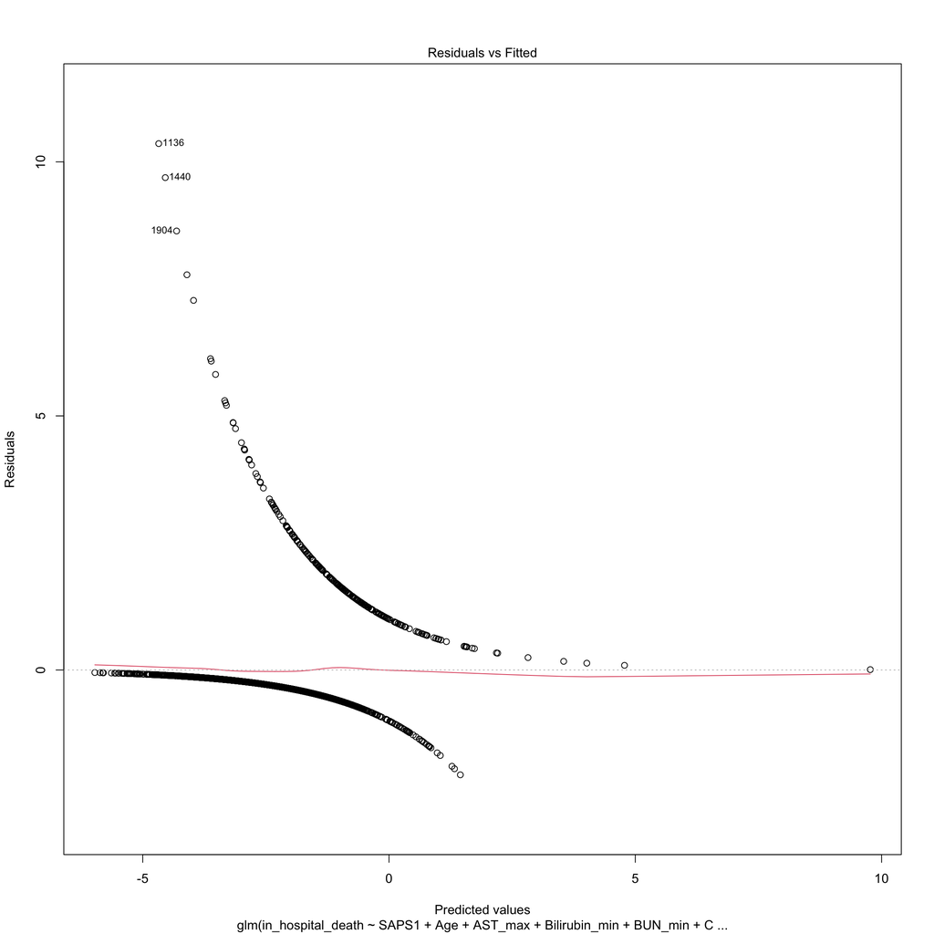

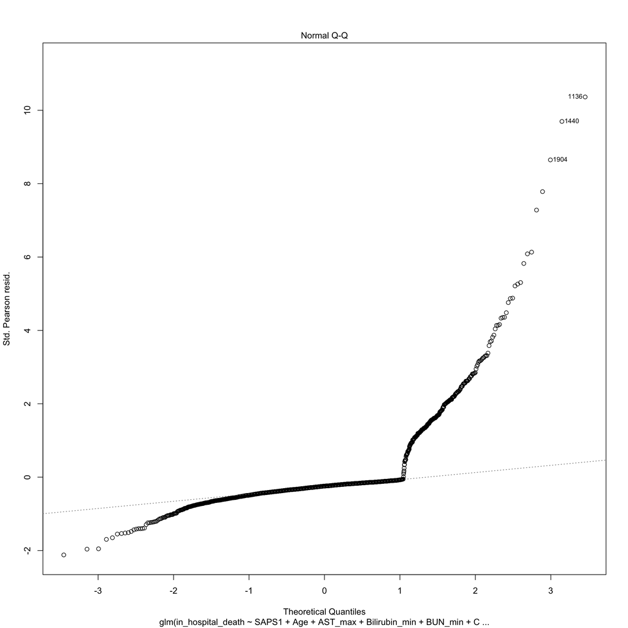

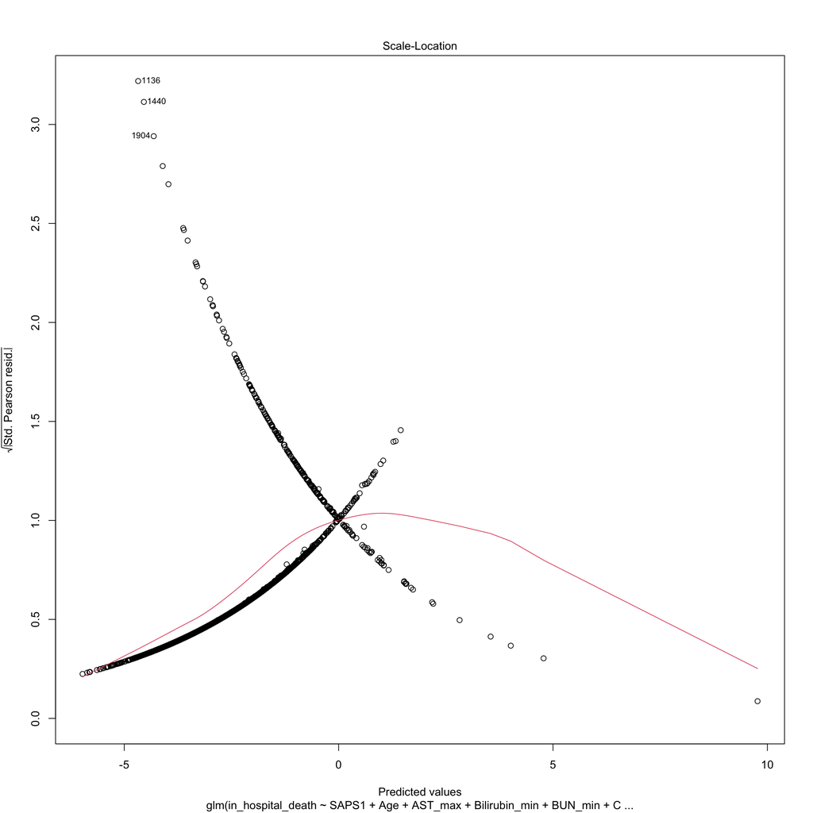

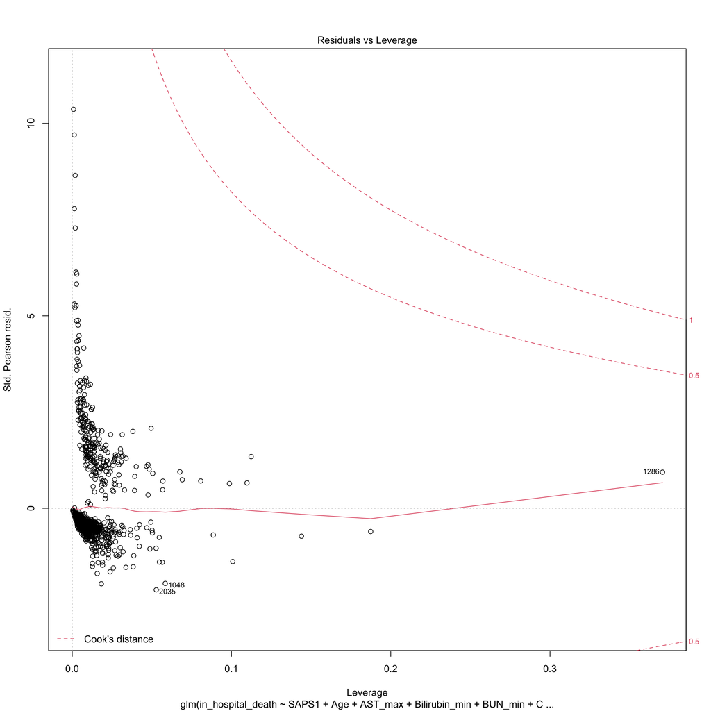

```r
plot(mod2)
```

```r
#check brier score
predicted_pro <- predict(mod2, type = "response")

Brier_score <- mean(predicted_pro - icu_removed_na$in_hospital_death ^2)
Brier_score
```

```
## [1] 1.460868e-15
```

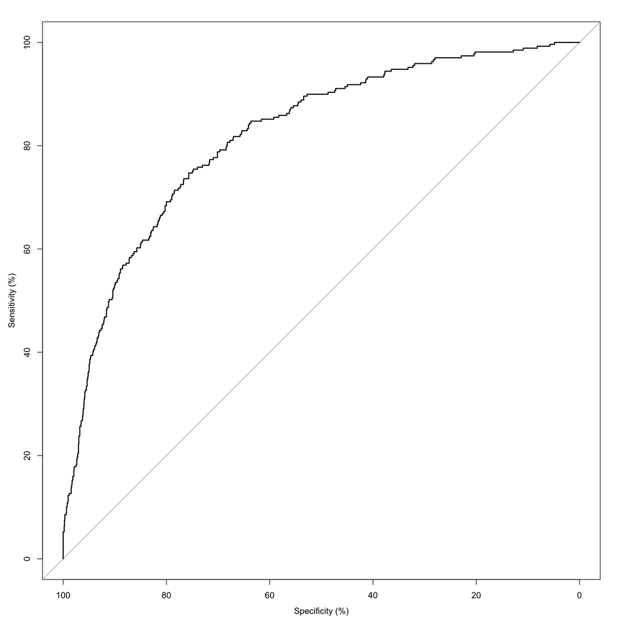

```
##
## Call:
## roc.default(response = icu_removed_na$in_hospital_death, predictor = icu_removed_na$predprob,     percent = TRUE, plot = TRUE)
##
## Data: icu_removed_na$predprob in 1550 controls (icu_removed_na$in_hospital_death 0) < 269 cases (icu_removed_na$in_hospital_death 1).
## Area under the curve: 81.88%
```

```r
icu_removed_na %>%mutate(predprob=predict(mod2, type="response")) -> icu_removed_na


roc(icu_removed_na$in_hospital_death, icu_removed_na$predprob, plot = TRUE, percent=TRUE)
```

# Task 2

In this task, you are required to develop a Cox proportional hazards survival model using the `icu_patients_df1` data set which adequately explains or predicts the length of survival indicated by the `Days` variable, with censoring as indicated by the `Status` variable. You should fit a series of models, maybe three or four, evaluating each one, before you present your final model. Your final model should **not** include all the predictor variables, just a small subset of them, which you have selected based on statistical significance and/or background knowledge. Aim for between five and ten predictor variables (slightly more or fewer is OK). It is perfectly acceptable to include predictor variables in your final model which are not statistically significant, as long as you justify their inclusion on medical or physiological grounds (you will not be marked down if your medical justification is not exactly correct, but do you best). You should assess each model you consider for goodness of fit and other relevant statistics, and you should assess your final model for violations of assumptions and perform other diagnostics which you think are relevant (and modify the model if indicated, or at least comment on the possible impact of what your diagnostics show). Finally, re-fit your final model to the unimputed data frame (`icu_patients_df0.rds`) and comment on any differences you find.

### Hints

1. Select an initial subset of explanatory variables that you will use to predict survival. Justify your choice.
2. Conduct basic exploratory data analysis on your variables of choice.
3. Fit appropriate univariate Cox proportional hazards models.
4. Fit an appropriate series of multivariable Cox proportional hazards models, justifying your approach. Assess each model you consider for goodness of fit and other relevant statistics.
5. Present your final model. Your final model should **not** include all the predictor variables, just a small subset of them, which you have selected based on statistical significance and/or background knowledge.
6. For your final model, present a set of diagnostic statistics and/or charts and comment on them.
7. Write a paragraph or two summarising the most important findings of your final model. Include the most important values from the statistical output, and a simple clinical interpretation.

**Create your response to this task here, as a mixture of embedded (`knitr`) R code and any resulting outputs, and explanatory or commentary text.**

```r
task2 <- coxph(Surv(Days, Status) ~ .-RecordID -in_hospital_death -Length_of_stay -Age, data = icu_removed_na)
summary(task2)
```

```
## Call:
## coxph(formula = Surv(Days, Status) ~ . - RecordID - in_hospital_death -
##     Length_of_stay - Age, data = icu_removed_na)
##
##   n= 1819, number of events= 684
##
##                                            coef  exp(coef)   se(coef)      z
## SAPS1                                 8.377e-02  1.087e+00  1.692e-02  4.950
## SOFA                                  4.195e-02  1.043e+00  2.257e-02  1.859
## Albumin_diff                          1.309e-01  1.140e+00  1.124e-01  1.164
## Albumin_max                           2.251e+00  9.500e+00  6.362e-01  3.539
## Albumin_min                          -2.031e+00  1.313e-01  5.811e-01 -3.494
## ALP_diff                             -2.411e-03  9.976e-01  1.265e-03 -1.906
## ALP_max                              -9.695e-03  9.904e-01  4.380e-03 -2.213
## ALP_min                               1.206e-02  1.012e+00  4.281e-03  2.816
## ALT_diff                              9.146e-04  1.001e+00  7.020e-04  1.303
## ALT_max                              -2.904e-04  9.997e-01  7.625e-04 -0.381
## ALT_min                              -1.074e-03  9.989e-01  6.883e-04 -1.560
## AST_diff                              1.920e-04  1.000e+00  4.934e-04  0.389
## AST_max                              -3.707e-05  1.000e+00  5.281e-04 -0.070
## AST_min                              -7.797e-04  9.992e-01  4.813e-04 -1.620
## Bilirubin_diff                       -1.124e-01  8.937e-01  5.089e-02 -2.208
## Bilirubin_max                         2.445e-01  1.277e+00  9.297e-02  2.630
## Bilirubin_min                        -1.646e-01  8.482e-01  9.040e-02 -1.821
## BUN_diff                             -6.160e-03  9.939e-01  5.739e-03 -1.073
## BUN_max                              -1.162e-02  9.885e-01  1.191e-02 -0.976
## BUN_min                               1.826e-02  1.018e+00  1.062e-02  1.720
## Cholesterol_diff                     -2.304e-04  9.998e-01  1.752e-03 -0.132
## Cholesterol_max                      -1.402e-02  9.861e-01  6.474e-03 -2.165
## Cholesterol_min                      -7.843e-03  9.922e-01  7.628e-03 -1.028
## Creatinine_diff                      -1.150e-02  9.886e-01  1.209e-01 -0.095
## Creatinine_max                        4.947e-01  1.640e+00  2.771e-01  1.785
## Creatinine_min                       -7.362e-01  4.789e-01  2.915e-01 -2.526
## FiO2_diff                            -7.596e-01  4.678e-01  6.138e-01 -1.238
## FiO2_max                             -5.319e-01  5.875e-01  5.099e-01 -1.043
## FiO2_min                             -2.858e-01  7.514e-01  3.761e-01 -0.760
## GCS_diff                              1.690e-02  1.017e+00  3.373e-02  0.501
## GCS_max                              -2.227e-01  8.003e-01  5.609e-02 -3.971
## GCS_min                               1.198e-01  1.127e+00  2.774e-02  4.318
## GenderMale                            2.381e-01  1.269e+00  9.447e-02  2.520
```

[output cut: 262 more lines]

```
## Urine_diff                            1.000361     0.9996 0.9980749   1.00265
## Urine_max                             0.999861     1.0001 0.9976353   1.00209
## Urine_min                             0.997002     1.0030 0.9947983   0.99921
## WBC_diff                              1.035513     0.9657 1.0146167   1.05684
## WBC_max                               0.969947     1.0310 0.9364780   1.00461
## WBC_min                               0.990177     1.0099 0.9511497   1.03081
## Weight_diff                           1.014526     0.9857 1.0087753   1.02031
## Weight_max                            0.975750     1.0249 0.9569371   0.99493
## Weight_min                            1.013460     0.9867 0.9940253   1.03327
## predprob                              5.260733     0.1901 1.6681142  16.59078
##
## Concordance= 0.769  (se = 0.008 )
## Likelihood ratio test= 657.9  on 100 df,   p=<2e-16
## Wald test            = 687.8  on 100 df,   p=<2e-16
## Score (logrank) test = 831.5  on 100 df,   p=<2e-16
```

## Save, knit and submit

**Reminder**: don’t forget to save this file, to knit it to check that everything works, and then submit via the drop box in OpenLearning.

## Submit your assessment

When you have finished, and are satisfied with your assessment solutions, and this file knits without errors and the output looks the way you want, then you should submit via the drop box in OpenLearning.

### Problems?

If you encounter problems with any part of the process described above, please contact the course convenor via OpenLearning as soon as possible so that the issues can be resolved in good time, and well before the assessment is due.

### Additional Information

The instructions are deliberately open-ended and less prescriptive than the individual assessments to allow you some latitude in what you do and how you go about the task. However, to complete the tasks and gain full marks, you only need to replicate or repeat the steps covered in the course - if you do most or all of the things described in the revalant chapters of the HDAT9600 course, full marks will be awarded.

Note also that with respect to the model fitting, there are no **right** or **wrong** answers when it comes to variable selection and other aspects of model specification. Deep understanding of the underlying medical concepts which govern patient treatment and outcomes in ICUs is not required or assumed, although you should try to gain some understanding of each variable using the links provided. You will not be marked down if your medical justifications are not exactly correct or complete, but do you best, and don’t hesitate to seek help from the course convenor.